# Individual Task 2: Sustainable Infrastructure and Responsible Investment Analysis

### 6.3.4 Missing data as a signal and correlations

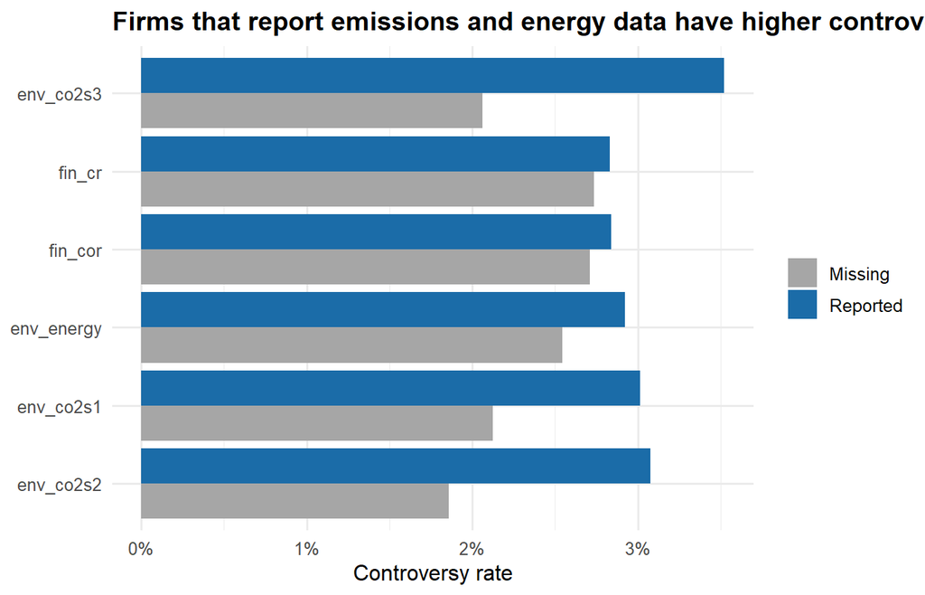

```r
train |>
  select(env_contro, all_of(na_vars)) |>
  pivot_longer(-env_contro, names_to = "variable", values_to = "value") |>
  group_by(variable, missing = if_else(is.na(value), "Missing", "Reported")) |>
  summarise(rate = mean(env_contro == "Yes"), n = n(), .groups = "drop") |>
  ggplot(aes(x = rate, y = reorder(variable, rate), fill = missing)) +
  geom_col(position = "dodge") +
  scale_x_continuous(labels = percent) +
  scale_fill_manual(values = c(Missing = col_grey, Reported = col_main)) +
  labs(title = "Firms that report emissions and energy data have higher controversy rates",
       x = "Controversy rate", y = NULL, fill = NULL)
```

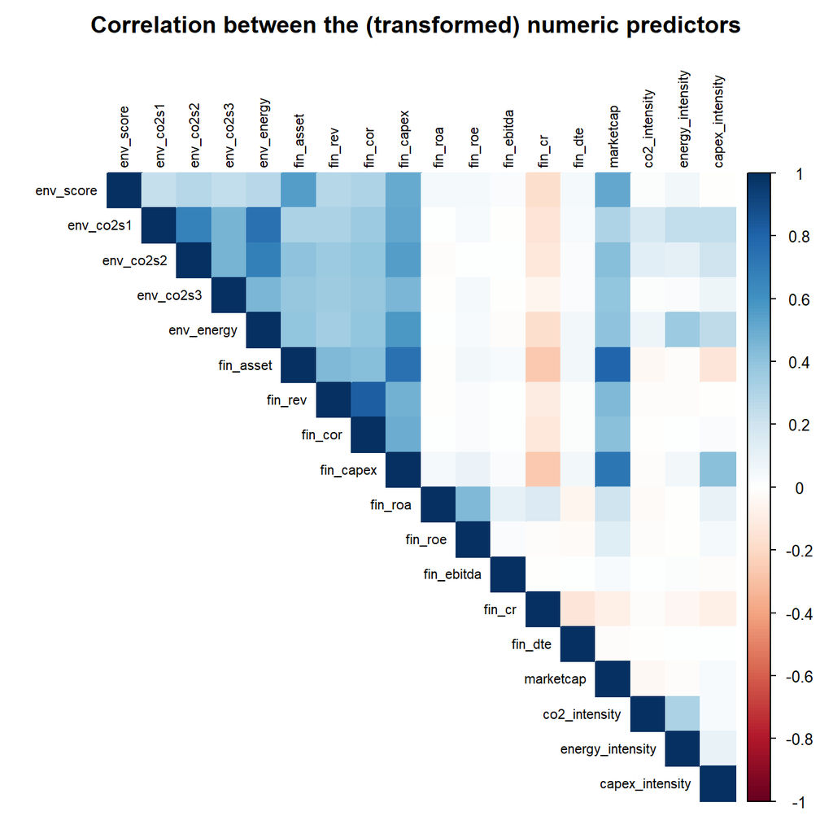

```r
corrplot(cor(select(train_baked, all_of(cont_vars)), use = "pairwise.complete.obs"),
         method = "color", type = "upper", tl.col = "black", tl.cex = 0.7,
         title = "Correlation between the (transformed) numeric predictors", mar = c(0, 0, 2, 0))
```

**Findings:** firms that report emissions data are more often involved in controversies than firms that do not report (probably because reporting firms are larger and more visible). The correlation plot shows strong correlations among the size variables (assets, revenue, costs, market capitalisation, capex) and among the emission variables. This multicollinearity can make logistic regression coefficients unstable, and it is a good reason to try PCA.

## 6.4 Dimensionality reduction (PCA) and cluster analysis

### 6.4.1 PCA on the numeric predictors:

Many predictors are correlated. PCA replaces them with a smaller number of uncorrelated components. I run it on the pre-processed training data (already transformed and standardised).

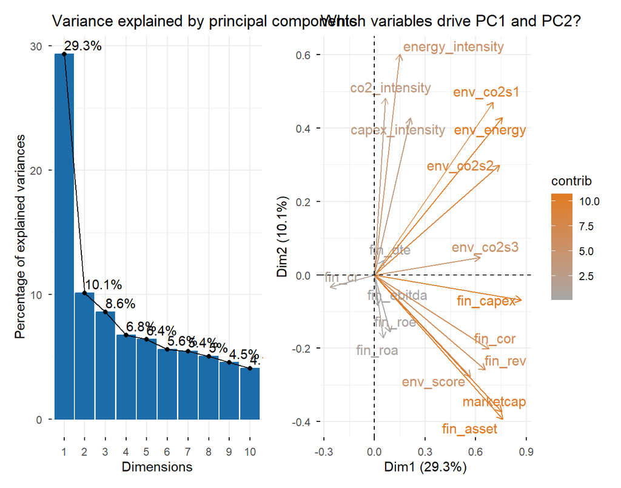

```r
pca_firm <- prcomp(select(train_baked, all_of(cont_vars)), scale. = FALSE)

wrap_plots(
  fviz_eig(pca_firm, addlabels = TRUE, ncp = 10, barfill = col_main, barcolor = col_main) +
    labs(title = "Variance explained by principal components"),
  fviz_pca_var(pca_firm, col.var = "contrib", gradient.cols = c(col_grey, col_accent), repel = TRUE) +
    labs(title = "Which variables drive PC1 and PC2?"),
  nrow = 1)
```

```r
cum_var <- summary(pca_firm)$importance["Cumulative Proportion", ]

tibble(components = c(3, 5, 8, 10), cumulative_variance = percent(cum_var[c(3, 5, 8, 10)], accuracy = 1)) |>
  kable(caption = "Cumulative variance explained")
```

Cumulative variance explained

| components | cumulative_variance |
| --- | --- |
| 3 | 48% |
| 5 | 61% |
| 8 | 77% |
| 10 | 86% |

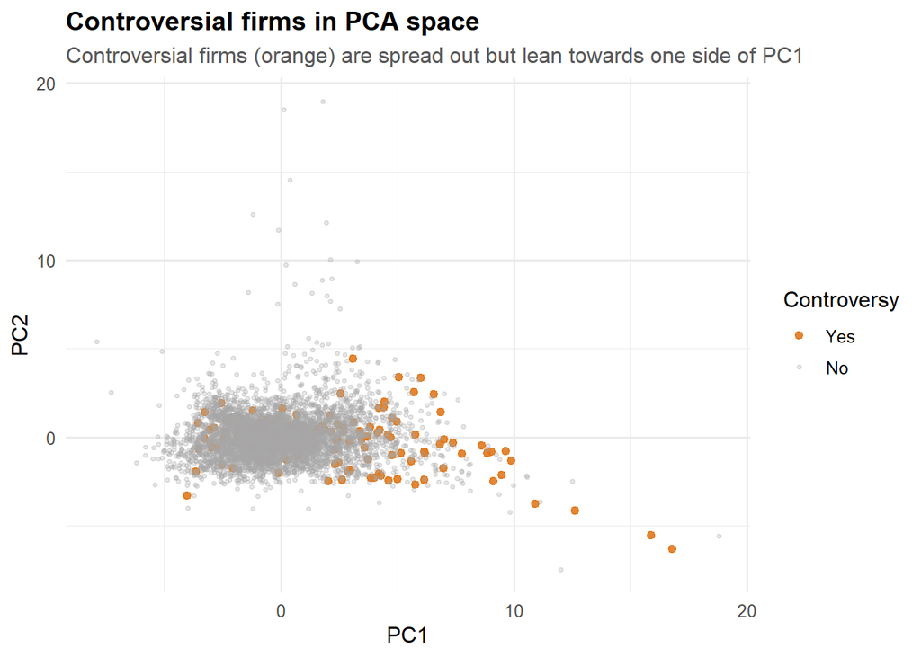

```r
pca_scores <- bind_cols(as_tibble(pca_firm$x[, 1:6]), env_contro = train_baked$env_contro)

ggplot(pca_scores |> arrange(env_contro), aes(PC1, PC2, colour = env_contro, alpha = env_contro, size = env_contro)) +
  geom_point() +
  scale_colour_manual(values = c(Yes = col_accent, No = col_grey)) +
  scale_alpha_manual(values = c(Yes = 0.9, No = 0.25)) +
  scale_size_manual(values = c(Yes = 1.8, No = 0.8)) +
  labs(title = "Controversial firms in PCA space",
       subtitle = "Controversial firms (orange) are spread out but lean towards one side of PC1",
       colour = "Controversy", alpha = "Controversy", size = "Controversy")
```

**Findings:** the first components capture the size and emissions dimension (PC1) and the profitability / leverage dimension (later components). The scatter plot shows that the two groups overlap heavily: controversial firms are not separated cleanly from the others. This warns me that the prediction task is hard and that I should not expect a near-perfect model. I will use PCA as an alternative pre-processing choice for logistic regression in 4.6.

### 6.4.2 Cluster analysis (k-means) of firms

Clustering is unsupervised, so it does not use the outcome. If some clusters of similar firms have a much higher controversy rate, this tells me there are firm “types” that carry more environmental risk.

I pick the number of clusters with the silhouette method (on a sample of firms, because silhouette needs all pairwise distances).

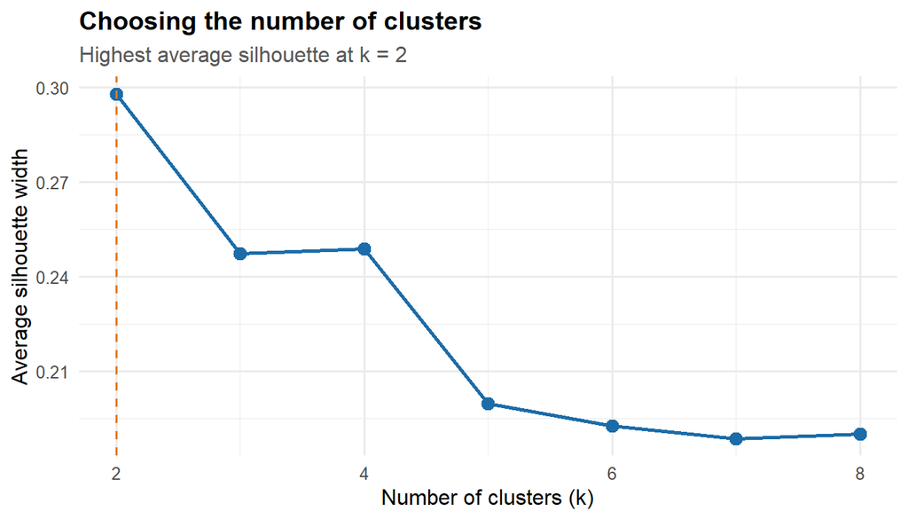

```r
samp <- pca_scores |> select(starts_with("PC")) |> slice_sample(n = 2000)

sil_tbl <- map_dfr(2:8, function(k) {
  km <- kmeans(samp, centers = k, nstart = 10)
  s  <- cluster::silhouette(km$cluster, dist(samp))
  tibble(k = k, avg_silhouette = mean(s[, "sil_width"]), wss = km$tot.withinss)
})

k_best <- sil_tbl$k[which.max(sil_tbl$avg_silhouette)]

ggplot(sil_tbl, aes(x = k, y = avg_silhouette)) +
  geom_line(colour = col_main, linewidth = 1) + geom_point(colour = col_main, size = 3) +
  geom_vline(xintercept = k_best, linetype = "dashed", colour = col_accent) +
  labs(title = "Choosing the number of clusters", subtitle = paste("Highest average silhouette at k =", k_best),
       x = "Number of clusters (k)", y = "Average silhouette width")
```

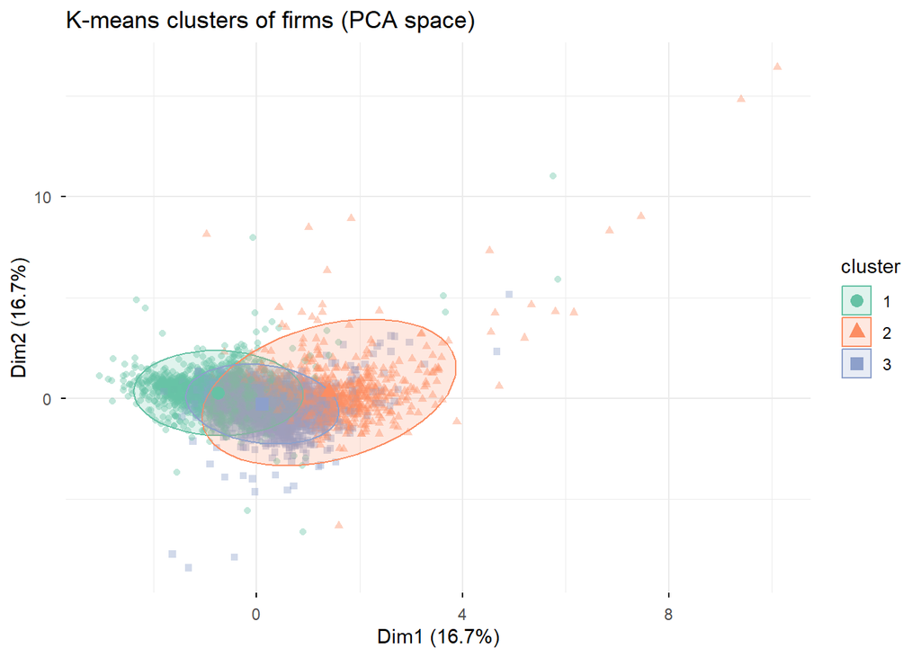

```r
k_use <- 3   # see the explanation below the plot
km_firm <- kmeans(select(pca_scores, starts_with("PC")), centers = k_use, nstart = 25)
pca_scores$cluster <- factor(km_firm$cluster)

fviz_cluster(km_firm, data = select(pca_scores, starts_with("PC")), geom = "point", alpha = 0.4,
             ellipse.type = "norm", palette = "Set2", ggtheme = theme_minimal()) +
  labs(title = "K-means clusters of firms (PCA space)")
```

```r
cluster_tbl <- train |>
  mutate(cluster = pca_scores$cluster) |>
  group_by(cluster) |>
  summarise(firms = n(),
            controversy_rate = mean(env_contro == "Yes"),
            median_marketcap_m = median(marketcap) / 1e6,
            median_env_score = median(env_score, na.rm = TRUE),
            share_climate_policy = mean(pol_climate == 1),
            .groups = "drop")

cluster_tbl |>
  mutate(controversy_rate = percent(controversy_rate, accuracy = 0.1), share_climate_policy = percent(share_climate_policy, accuracy = 1)) |>
  kable(digits = 1, format.args = list(big.mark = ","), caption = "Profile of the firm clusters")
```

Profile of the firm clusters

| cluster | firms | controversy_rate | median_marketcap_m | median_env_score | share_climate_policy |
| --- | --- | --- | --- | --- | --- |
| 1 | 1,975 | 1.6% | 282.9 | 24.9 | 42% |
| 2 | 830 | 8.0% | 9,455.5 | 72.8 | 80% |
| 3 | 2,651 | 2.1% | 2,321.4 | 50.8 | 60% |

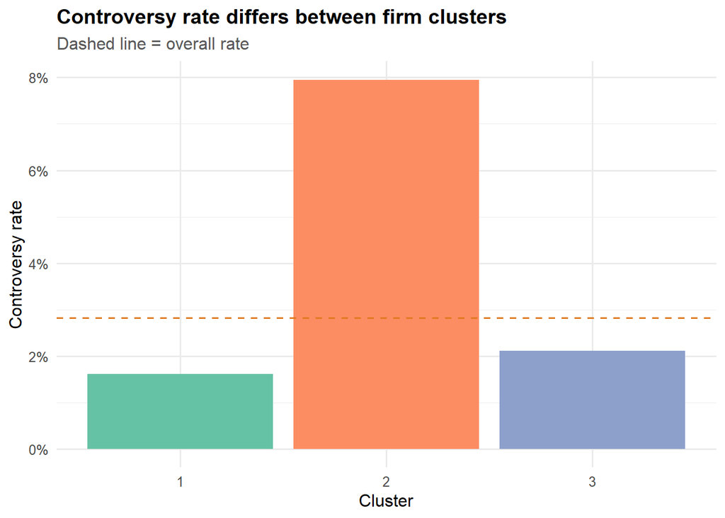

```r
ggplot(cluster_tbl, aes(x = cluster, y = controversy_rate, fill = cluster)) +
  geom_col(show.legend = FALSE) +
  geom_hline(yintercept = base_rate, linetype = "dashed", colour = col_accent) +
  scale_y_continuous(labels = percent) +
  scale_fill_brewer(palette = "Set2") +
  labs(title = "Controversy rate differs between firm clusters", subtitle = "Dashed line = overall rate",
       x = "Cluster", y = "Controversy rate")
```

**Findings:** The silhouette method gives its highest score at k = 2, but with k = 2 the split is very coarse (roughly “big” vs “small” firms). I used k = 3 because the silhouette is still reasonable and the third cluster separates out a small group of very large firms, which is more useful for risk screening. The table and chart show that **cluster 2** is the high-risk group: it has 830 firms (about 15% of the training data) but a controversy rate of 8.0%, which is about 2.8 times the overall rate (2.8%).

These are the largest firms (median market capitalisation about USD 9,455 million) with the highest environmental scores and the highest share of climate policies. The other clusters sit near or below the average.

This agrees with the Wilcoxon and policy results: **large, well-disclosing firms attract the most controversy**. Because the clusters were built without the outcome, this link is genuine information that the supervised models can also use.

## 6.5 Resampling plan and metrics

I use 5-fold cross-validation stratified by the outcome on the training set. The training firms are split into five groups; each model is trained on four groups and scored on the fifth, and this is repeated five times. Every candidate model and every tuning value is therefore scored on data it was not trained on, which protects against overfitting. The pre-processing is re-learned inside each fold, so the validation fold never influences the medians or scaling.

I tune on **ROC AUC** and also record **PR AUC** (computed as average precision). The helper functions below build the folds, the metrics and the cross-validation loop.

```r
fold_id <- integer(nrow(train))
for (cl in c("Yes", "No")) {  # stratified: folds keep the share of positives
  i <- which(train$env_contro == cl)
  fold_id[i] <- sample(rep(1:5, length.out = length(i)))
}
table(fold_id, train$env_contro)
```

```
##
## fold_id  Yes   No
##       1   31 1061
##       2   31 1061
##       3   31 1060
##       4   31 1060
##       5   30 1060
```

```r
# pre-processing is learned INSIDE each fold (no leakage from the validation fold)
fold_data <- map(1:5, function(f) {
  p <- learn_prep(train[fold_id != f, ])
  list(tr = apply_prep(train[fold_id != f, ], p), te = apply_prep(train[fold_id == f, ], p),
       te_rows = which(fold_id == f))
})

# metrics
y01     <- function(y) as.integer(y == "Yes")
auc_fn  <- function(y, p) as.numeric(pROC::auc(y01(y), p, levels = c(0, 1), direction = "<", quiet = TRUE))
ap_fn   <- function(y, p) { o <- order(p, decreasing = TRUE); yy <- y01(y)[o]; sum((cumsum(yy) / seq_along(yy))[yy == 1]) / sum(yy) }   # average precision (PR AUC)
```

```r
# every model function: fit on `tr`, return P(controversy = Yes) for `te`
x_of <- function(d) as.data.frame(select(d, -env_contro))

fit_logit <- function(tr, te, ...) {
  m <- suppressWarnings(glm(y ~ ., data = cbind(x_of(tr), y = y01(tr$env_contro)), family = binomial))
  suppressWarnings(predict(m, x_of(te), type = "response"))
}

fit_logit_pca <- function(tr, te, num_comp, ...) {
  pc   <- prcomp(tr[cont_vars])
  rest <- setdiff(names(tr), c(cont_vars, "env_contro"))
  mk   <- function(d) cbind(as.data.frame(predict(pc, d[cont_vars])[, 1:num_comp, drop = FALSE]), d[rest])
  m <- suppressWarnings(glm(y ~ ., data = cbind(mk(tr), y = y01(tr$env_contro)), family = binomial))
  suppressWarnings(predict(m, mk(te), type = "response"))
}

fit_enet <- function(tr, te, alpha, lambdas, ...) { # returns one column per lambda
  m <- glmnet(as.matrix(x_of(tr)), y01(tr$env_contro), family = "binomial", alpha = alpha, lambda = lambdas)
  predict(m, as.matrix(x_of(te)), s = lambdas, type = "response")
}

fit_tree <- function(tr, te, cp, maxdepth, minsplit, ...) {
  m <- rpart(env_contro ~ ., data = tr, method = "class", parms = list(prior = c(0.5, 0.5)),
             control = rpart.control(cp = cp, maxdepth = maxdepth, minsplit = minsplit, xval = 0))
  predict(m, te, type = "prob")[, "Yes"]
}

fit_knn <- function(tr, te, k, ...) {
  kk <- class::knn(x_of(tr), x_of(te), cl = tr$env_contro, k = k, prob = TRUE)
  ifelse(kk == "Yes", attr(kk, "prob"), 1 - attr(kk, "prob"))
}

# cross-validation of one model over a grid of settings (one row = one setting)
cv_grid <- function(fun, grid) {
  map_dfr(seq_len(nrow(grid)), function(i) {
    per_fold <- map_dfr(1:5, function(f) {
      d <- fold_data[[f]]
      p <- do.call(fun, c(list(tr = d$tr, te = d$te), as.list(grid[i, , drop = FALSE])))
      tibble(roc = auc_fn(d$te$env_contro, p), pr = ap_fn(d$te$env_contro, p))
    })
    bind_cols(grid[i, , drop = FALSE],
              tibble(mean_roc_auc = mean(per_fold$roc), se_roc_auc = sd(per_fold$roc) / sqrt(5),
                     mean_pr_auc  = mean(per_fold$pr),  se_pr_auc  = sd(per_fold$pr)  / sqrt(5)))
  })
}

# out-of-fold predictions for one chosen setting (every training firm predicted by a model that did not see it)
oof_pred <- function(fun, params) {
  out <- numeric(nrow(train))
  for (f in 1:5) {
    d <- fold_data[[f]]
    out[d$te_rows] <- do.call(fun, c(list(tr = d$tr, te = d$te), params))
  }
  out
}
```

## 6.6 Models

I build five candidate models, all using the same cross-validation folds so that the comparison is fair.

**1. Logistic regression:** Linear model of the log-odds; easy to interpret (odds ratios). I judge it by AUC and choose a low threshold later.

**2. Logistic regression + PCA:** Same, but on principal components to remove multicollinearity. I tune the number of components.

**3. Elastic-net logistic regression:** Logistic regression with a penalty that shrinks unimportant coefficients towards zero (a mix of ridge and lasso), which helps when there are many correlated predictors. I tune the penalty and the ridge/lasso mixture (`alpha`).

**4. Decision tree:** Rules of the form “if X > a then …”; easy to explain to managers. I give both classes equal prior weight (`prior = c(0.5, 0.5)`), so the tree does not ignore the rare class.

**5. K-nearest neighbours (KNN):** Predicts from the most similar firms | I tune the number of neighbours.

The model functions are in the chunk above (`fit_logit`, `fit_logit_pca`, `fit_enet`, `fit_tree`, `fit_knn`). Each one fits on a training set and returns the predicted probability of a controversy for new firms.

### 6.6.1 Fitting and tuning with cross-validation

```r
res_log <- cv_grid(fit_logit, tibble(dummy = 1))

res_pca <- cv_grid(fit_logit_pca, tibble(num_comp = c(3, 5, 8, 10, 12, 15)))

# elastic net: for each alpha (0 = ridge, 1 = lasso) fit the whole penalty path at once
lam_grid <- 10^seq(-0.5, -3, length.out = 20) # decreasing path (glmnet needs to start from a large penalty)
res_en <- map_dfr(c(0.25, 0.5, 1), function(a) {
  per_fold <- map(1:5, function(f) {
    d <- fold_data[[f]]
    p <- fit_enet(d$tr, d$te, alpha = a, lambdas = lam_grid)
    tibble(lambda = lam_grid, roc = apply(p, 2, auc_fn, y = d$te$env_contro), pr = apply(p, 2, ap_fn, y = d$te$env_contro))
  }) |> bind_rows(.id = "fold")
  per_fold |> group_by(lambda) |>
    summarise(mean_roc_auc = mean(roc), se_roc_auc = sd(roc) / sqrt(5),
              mean_pr_auc = mean(pr), se_pr_auc = sd(pr) / sqrt(5), .groups = "drop") |>
    mutate(alpha = a, .before = 1)
})

tree_grid <- expand_grid(cp = 10^seq(-3, -1.2, length.out = 5), maxdepth = c(2, 4, 6, 8), minsplit = c(10, 60))
res_tree <- cv_grid(fit_tree, tree_grid)

res_knn <- cv_grid(fit_knn, tibble(k = c(5, 11, 21, 41, 71, 101, 151)))

best_pca  <- slice_max(res_pca,  mean_roc_auc, n = 1, with_ties = FALSE)
best_en   <- slice_max(res_en,   mean_roc_auc, n = 1, with_ties = FALSE)
best_tree <- slice_max(res_tree, mean_roc_auc, n = 1, with_ties = FALSE)
best_knn  <- slice_max(res_knn,  mean_roc_auc, n = 1, with_ties = FALSE)

list(PCA = best_pca, ElasticNet = best_en, Tree = best_tree, KNN = best_knn)
```

```
## $PCA
## # A tibble: 1 × 5
##   num_comp mean_roc_auc se_roc_auc mean_pr_auc se_pr_auc
##      <dbl>        <dbl>      <dbl>       <dbl>     <dbl>
## 1       15        0.689     0.0168       0.127    0.0197
##
## $ElasticNet
## # A tibble: 1 × 6
##   alpha lambda mean_roc_auc se_roc_auc mean_pr_auc se_pr_auc
##   <dbl>  <dbl>        <dbl>      <dbl>       <dbl>     <dbl>
## 1  0.25 0.0113        0.707    0.00775       0.155    0.0166
##
## $Tree
## # A tibble: 1 × 7
##       cp maxdepth minsplit mean_roc_auc se_roc_auc mean_pr_auc se_pr_auc
##    <dbl>    <dbl>    <dbl>        <dbl>      <dbl>       <dbl>     <dbl>
## 1 0.0224        4       10        0.647     0.0145      0.0720   0.00316
##
## $KNN
## # A tibble: 1 × 5
##       k mean_roc_auc se_roc_auc mean_pr_auc se_pr_auc
##   <dbl>        <dbl>      <dbl>       <dbl>     <dbl>
## 1    41        0.654     0.0126       0.146    0.0197
```

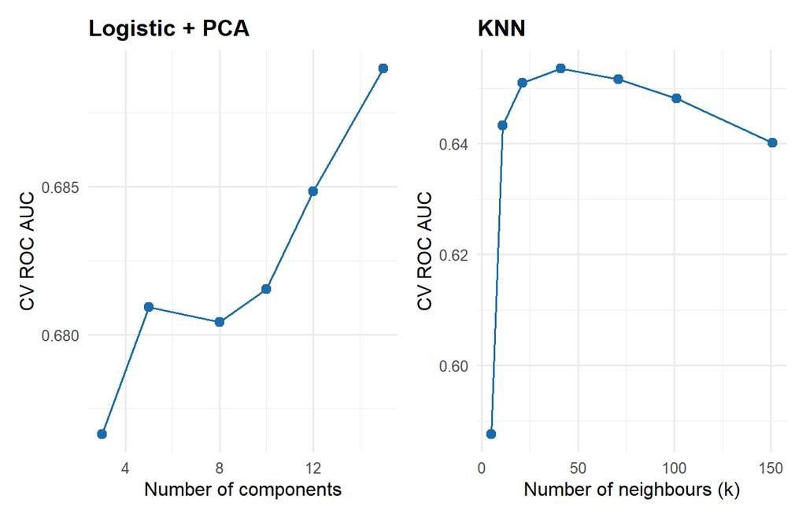

```r
p_pca <- ggplot(res_pca, aes(num_comp, mean_roc_auc)) + geom_line(colour = col_main) + geom_point(colour = col_main, size = 2.5) +
  labs(title = "Logistic + PCA", x = "Number of components", y = "CV ROC AUC")
p_knn <- ggplot(res_knn, aes(k, mean_roc_auc)) + geom_line(colour = col_main) + geom_point(colour = col_main, size = 2.5) +
  labs(title = "KNN", x = "Number of neighbours (k)", y = "CV ROC AUC")
p_en <- ggplot(res_en, aes(log10(lambda), mean_roc_auc, colour = factor(alpha))) + geom_line(linewidth = 1) +
  scale_colour_manual(values = c("#1B6CA8", "#E07A1F", "#4daf4a")) +
  labs(title = "Elastic-net logistic regression", x = "log10(penalty)", y = "CV ROC AUC", colour = "alpha\n(1 = lasso)")
p_tree <- ggplot(res_tree, aes(log10(cp), mean_roc_auc, colour = factor(minsplit))) + geom_line() + geom_point() +
  facet_wrap(~ paste("max depth =", maxdepth), nrow = 1) +
  labs(title = "Decision tree", x = "log10(complexity parameter cp)", y = "CV ROC AUC", colour = "min. split")

wrap_plots(p_pca, p_knn, nrow = 1)
```

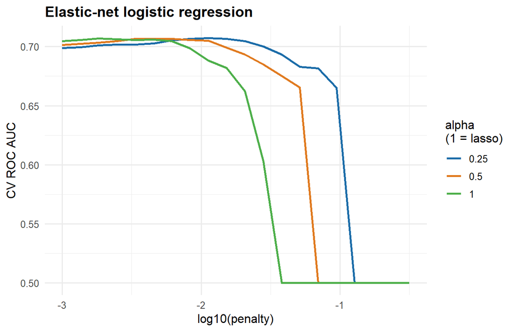

```r
p_en
```

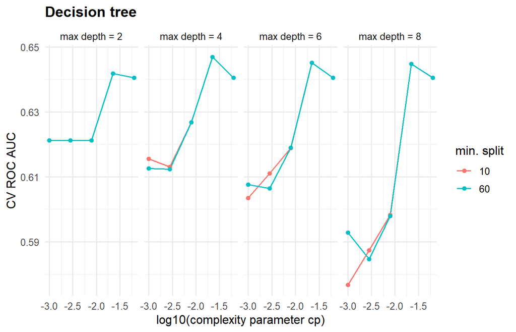

```r
p_tree
```

**Findings:** The tuning plots show how performance changes with the settings. For KNN, very small *k* gives noisy predictions (high variance) and larger *k* smooths the predictions, which improves AUC until it flattens. For the PCA model, too few components throw away useful information, while more components approach the plain logistic model. For the elastic net, too much penalty shrinks every coefficient towards zero and too little behaves like the plain logistic regression (many noisy coefficients), so performance peaks in between, and a mixture closer to ridge/lasso is chosen by the cross-validation. For the tree, very deep trees with small leaves can overfit; I choose the setting with the best cross-validated ROC AUC for each model.

## 6.7 Comparing the models using cross-validation

```r
cv_table <- bind_rows(
  res_log  |> mutate(model = "Logistic regression"),
  best_pca |> mutate(model = "Logistic regression + PCA"),
  best_en  |> mutate(model = "Elastic-net logistic regression"),
  best_tree |> mutate(model = "Decision tree"),
  best_knn |> mutate(model = "KNN")
) |>
  select(model, mean_roc_auc, se_roc_auc, mean_pr_auc, se_pr_auc) |>
  arrange(desc(mean_roc_auc))

kable(cv_table, digits = 3, caption = "Cross-validated performance (5 folds, training data)")
```

Cross-validated performance (5 folds, training data)

| model | mean_roc_auc | se_roc_auc | mean_pr_auc | se_pr_auc |
| --- | --- | --- | --- | --- |
| Elastic-net logistic regression | 0.707 | 0.008 | 0.155 | 0.017 |
| Logistic regression | 0.693 | 0.016 | 0.134 | 0.024 |
| Logistic regression + PCA | 0.689 | 0.017 | 0.127 | 0.020 |
| KNN | 0.654 | 0.013 | 0.146 | 0.020 |
| Decision tree | 0.647 | 0.015 | 0.072 | 0.003 |

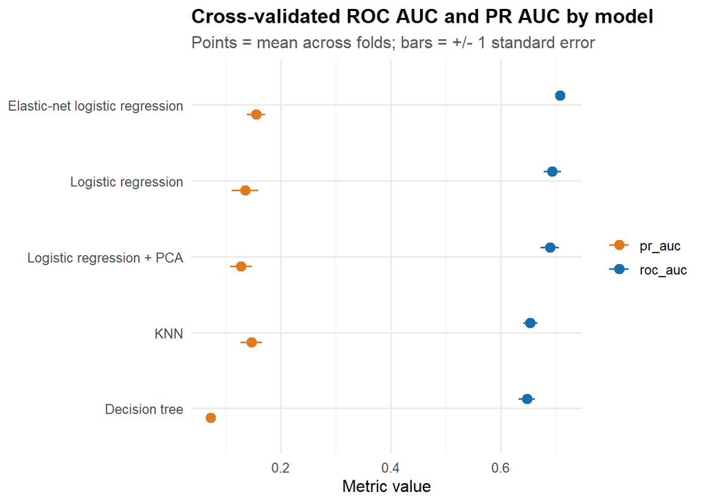

```r
cv_summary <- cv_table |>
  pivot_longer(-model, names_to = c(".value", "metric"), names_pattern = "(mean|se)_(.*)")

ggplot(cv_summary, aes(x = mean, y = reorder(model, mean), colour = metric)) +
  geom_pointrange(aes(xmin = mean - se, xmax = mean + se), position = position_dodge(width = 0.5)) +
  scale_colour_manual(values = c(pr_auc = col_accent, roc_auc = col_main)) +
  labs(title = "Cross-validated ROC AUC and PR AUC by model",
       subtitle = "Points = mean across folds; bars = +/- 1 standard error", x = "Metric value", y = NULL, colour = NULL)
```

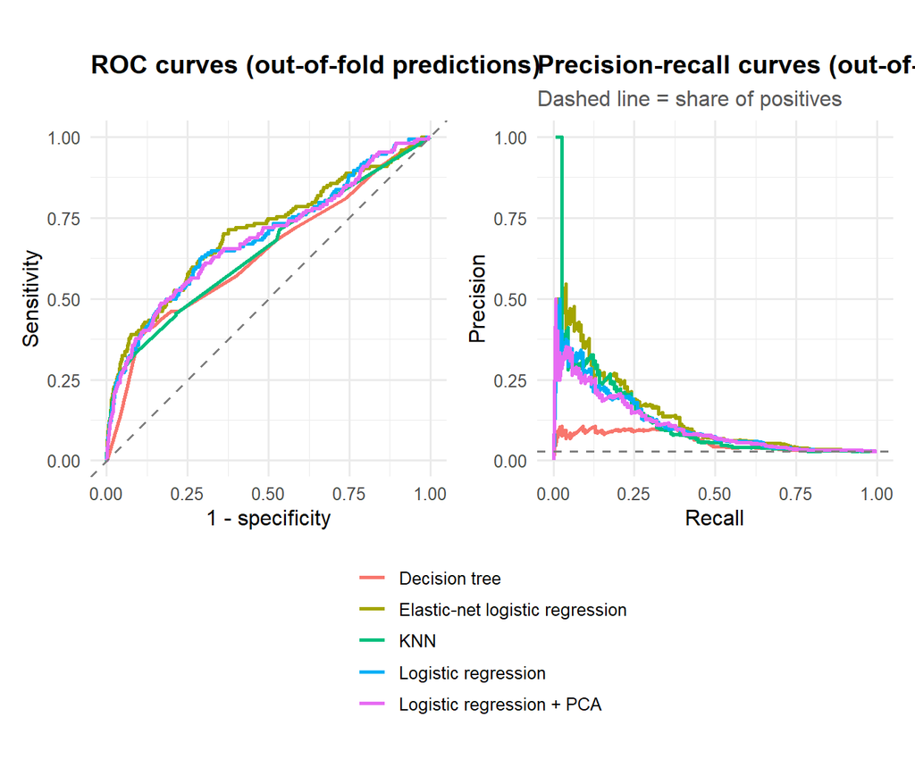

```r
fit_enet_best <- function(tr, te, alpha, lambda, ...) {
  # one lambda taken from the fitted path
  p <- fit_enet(tr, te, alpha, lam_grid)
  p[, which.min(abs(log10(lam_grid) - log10(lambda)))]
}

oof_preds <- bind_rows(
  tibble(model = "Logistic regression", .pred_Yes = oof_pred(fit_logit, list())),
  tibble(model = "Logistic regression + PCA", .pred_Yes = oof_pred(fit_logit_pca, list(num_comp = best_pca$num_comp))),
  tibble(model = "Elastic-net logistic regression", .pred_Yes = oof_pred(fit_enet_best, list(alpha = best_en$alpha, lambda = best_en$lambda))),
  tibble(model = "Decision tree", .pred_Yes = oof_pred(fit_tree, list(cp = best_tree$cp, maxdepth = best_tree$maxdepth, minsplit = best_tree$minsplit))),
  tibble(model = "KNN", .pred_Yes = oof_pred(fit_knn, list(k = best_knn$k)))
) |> mutate(env_contro = rep(train$env_contro, 5))

roc_points <- function(y, p) {
  r <- pROC::roc(y01(y), p, levels = c(0, 1), direction = "<", quiet = TRUE)
  tibble(fpr = 1 - r$specificities, tpr = r$sensitivities)
}
pr_points <- function(y, p) {
  o <- order(p, decreasing = TRUE); yy <- y01(y)[o]
  tibble(recall = cumsum(yy) / sum(yy), precision = cumsum(yy) / seq_along(yy))
}

roc_df <- oof_preds |> group_by(model) |> group_modify(~ roc_points(.x$env_contro, .x$.pred_Yes)) |> ungroup()
pr_df  <- oof_preds |> group_by(model) |> group_modify(~ pr_points(.x$env_contro, .x$.pred_Yes)) |> ungroup()

roc_plot <- ggplot(roc_df, aes(fpr, tpr, colour = model)) + geom_line(linewidth = 0.9) +
  geom_abline(linetype = "dashed", colour = "grey50") + coord_equal() +
  labs(title = "ROC curves (out-of-fold predictions)", x = "1 - specificity", y = "Sensitivity", colour = NULL) +
  theme(legend.position = "bottom", legend.direction = "vertical")
pr_plot <- ggplot(pr_df, aes(recall, precision, colour = model)) + geom_line(linewidth = 0.9) +
  geom_hline(yintercept = mean(train$env_contro == "Yes"), linetype = "dashed", colour = "grey50") +
  labs(title = "Precision-recall curves (out-of-fold)", subtitle = "Dashed line = share of positives", x = "Recall", y = "Precision", colour = NULL) +
  theme(legend.position = "bottom", legend.direction = "vertical")

wrap_plots(roc_plot, pr_plot, nrow = 1, guides = "collect") & theme(legend.position = "bottom")
```

```r
best_name   <- cv_table$model[1]
best_cv_auc <- cv_table$mean_roc_auc[1]
```

## 6.8 Choosing the decision threshold (using the cost of errors)

A classification model gives a probability, and I must choose a cut-off above which a firm is flagged. The default cut-off of 0.5 is far too high here, because predicted probabilities are small when the event is rare. Since false positives are cheap and false negatives are costly, I choose the cut-off that maximises the F2 score on the out-of-fold training predictions (not on the test set). F2 is the F-score that treats recall as twice as important as precision. I also show some alternative operating points.

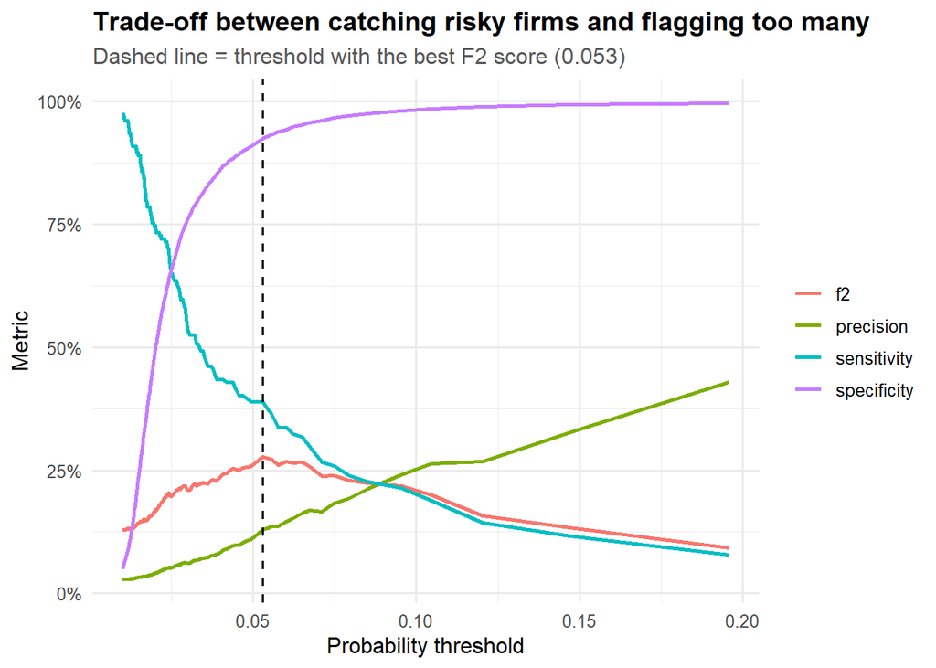

```r
conf_counts <- function(truth, pred_class) {
  c(TP = sum(truth == "Yes" & pred_class == "Yes"), FN = sum(truth == "Yes" & pred_class == "No"),
    FP = sum(truth == "No"  & pred_class == "Yes"), TN = sum(truth == "No"  & pred_class == "No"))
}
class_metrics <- function(truth, pred_class) {
  n <- conf_counts(truth, pred_class)
  sens <- n["TP"] / (n["TP"] + n["FN"]); spec <- n["TN"] / (n["TN"] + n["FP"])
  prec <- if (n["TP"] + n["FP"] > 0) n["TP"] / (n["TP"] + n["FP"]) else 0
  tibble(.metric  = c("sens", "spec", "precision", "accuracy", "bal_accuracy", "f2"),
         .estimate = c(sens, spec, prec, (n["TP"] + n["TN"]) / sum(n), (sens + spec) / 2,
                       5 * n["TP"] / (5 * n["TP"] + 4 * n["FN"] + n["FP"])) |> unname())
}

oof_best <- filter(oof_preds, model == best_name)

eval_threshold <- function(t, dat) {
  pred <- if_else(dat$.pred_Yes >= t, "Yes", "No")
  m <- class_metrics(dat$env_contro, pred)
  tibble(threshold = t, sensitivity = m$.estimate[1], specificity = m$.estimate[2],
         precision = m$.estimate[3], f2 = m$.estimate[6], flagged = mean(pred == "Yes"))
}

cand_thresholds <- unique(quantile(oof_best$.pred_Yes, probs = seq(0.05, 0.995, by = 0.005)))
thr_tbl  <- map_dfr(cand_thresholds, eval_threshold, dat = oof_best)
best_thr <- slice_max(thr_tbl, f2, n = 1, with_ties = FALSE)

thr_tbl |>
  pivot_longer(c(sensitivity, specificity, precision, f2), names_to = "metric", values_to = "value") |>
  ggplot(aes(x = threshold, y = value, colour = metric)) +
  geom_line(linewidth = 1) +
  geom_vline(xintercept = best_thr$threshold, linetype = "dashed") +
  scale_y_continuous(labels = percent) +
  labs(title = "Trade-off between catching risky firms and flagging too many",
       subtitle = paste0("Dashed line = threshold with the best F2 score (", round(best_thr$threshold, 3), ")"),
       x = "Probability threshold", y = "Metric", colour = NULL)
```

```r
targets <- c(0.60, 0.70, 0.80, 0.90)
op_points <- map_dfr(targets, function(tg) {
  thr_tbl |> filter(sensitivity >= tg) |> slice_max(threshold, n = 1, with_ties = FALSE) |> mutate(target_recall = tg)
})

bind_rows(best_thr |> mutate(target_recall = NA_real_, choice = "Best F2 (my choice)"),
          op_points |> mutate(choice = paste0("Recall at least ", percent(target_recall)))) |>
  transmute(Choice = choice, Threshold = round(threshold, 3),
            Sensitivity = percent(sensitivity, accuracy = 1), Specificity = percent(specificity, accuracy = 1),
            Precision = percent(precision, accuracy = 0.1), `Firms flagged` = percent(flagged, accuracy = 1)) |>
  kable(caption = "Operating points on out-of-fold training predictions")
```

Operating points on out-of-fold training predictions

| Choice | Threshold | Sensitivity | Specificity | Precision | Firms flagged |
| --- | --- | --- | --- | --- | --- |
| Best F2 (my choice) | 0.053 | 39% | 92% | 12.9% | 9% |
| Recall at least 60% | 0.028 | 61% | 72% | 5.9% | 29% |
| Recall at least 70% | 0.024 | 70% | 64% | 5.3% | 37% |
| Recall at least 80% | 0.017 | 81% | 35% | 3.5% | 66% |
| Recall at least 90% | 0.014 | 90% | 20% | 3.2% | 80% |

**Findings:** The plot shows the classic trade-off: lowering the threshold catches more controversial firms (higher sensitivity) but flags many more firms (lower precision and specificity). The table translates this into workload. For example, to catch a given share of risky firms the experts must review the percentage of firms shown in the “Firms flagged” column. Because the model is only moderately accurate, catching most risky firms needs a very low threshold and a large review workload (catching about 80% of risky firms means reviewing more than half of all firms). I use the best-F2 threshold as my default recommendation because it reflects the stated cost structure (missing a risky firm is worse than reviewing a safe one) while keeping the review list short. If the experts have more capacity, the manager can pick a lower threshold from the table; if capacity is tight, a higher one.

## 6.9 Final evaluation on the test set

Now I refit the best model on the whole training set, predict on the test set (the first time it is used), and apply the threshold I chose in 4.8. This gives an honest estimate of how the model would work on new firms.

```r
predict_final <- function(name, tr, te) {
  switch(name,
    "Logistic regression" = fit_logit(tr, te),
    "Logistic regression + PCA" = fit_logit_pca(tr, te, num_comp = best_pca$num_comp),
    "Elastic-net logistic regression" = fit_enet_best(tr, te, best_en$alpha, best_en$lambda),
    "Decision tree" = fit_tree(tr, te, best_tree$cp, best_tree$maxdepth, best_tree$minsplit),
    "KNN" = fit_knn(tr, te, best_knn$k))
}

test_pred <- tibble(env_contro = test$env_contro,
                    .pred_Yes  = predict_final(best_name, train_baked, test_baked)) |>
  mutate(pred_class   = factor(if_else(.pred_Yes >= best_thr$threshold, "Yes", "No"), levels = c("Yes", "No")),
         pred_default = factor(if_else(.pred_Yes >= 0.5, "Yes", "No"), levels = c("Yes", "No")))

tibble(metric = c("roc_auc", "pr_auc"),
       estimate = c(auc_fn(test_pred$env_contro, test_pred$.pred_Yes), ap_fn(test_pred$env_contro, test_pred$.pred_Yes))) |>
  kable(digits = 3, caption = paste("Test-set AUC for the final model:", best_name))
```

Test-set AUC for the final model: Elastic-net logistic regression

| metric | estimate |
| --- | --- |
| roc_auc | 0.681 |
| pr_auc | 0.182 |

```r
tm     <- class_metrics(test_pred$env_contro, test_pred$pred_class)
tm_def <- class_metrics(test_pred$env_contro, test_pred$pred_default)

tibble(metric = tm$.metric, `My threshold` = tm$.estimate, `Default 0.5` = tm_def$.estimate) |>
  kable(digits = 3, caption = "Test-set performance: my threshold vs the default 0.5 cut-off")
```

Test-set performance: my threshold vs the default 0.5 cut-off

| metric | My threshold | Default 0.5 |
| --- | --- | --- |
| sens | 0.423 | 0.019 |
| spec | 0.932 | 1.000 |
| precision | 0.155 | 1.000 |
| accuracy | 0.918 | 0.972 |
| bal_accuracy | 0.678 | 0.510 |
| f2 | 0.314 | 0.024 |

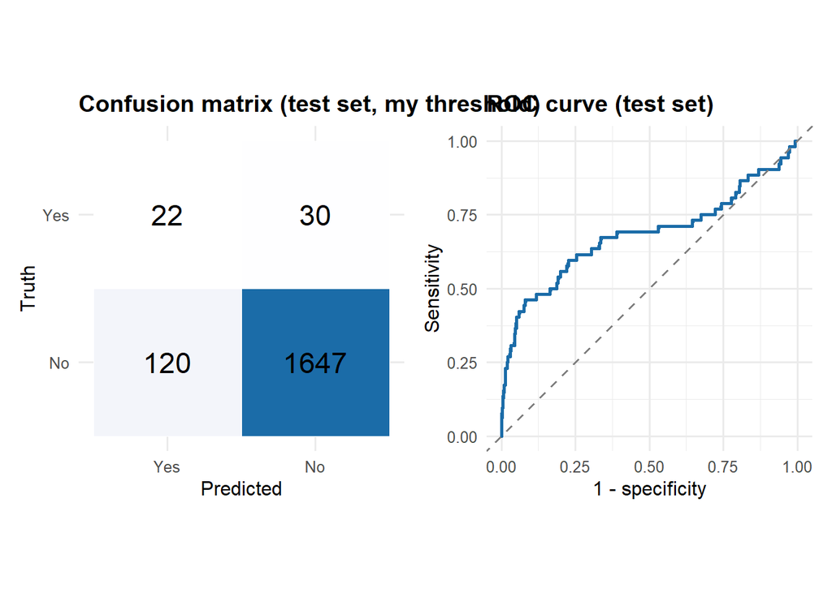

```r
cm <- table(Truth = test_pred$env_contro, Predicted = test_pred$pred_class)

cm_plot <- as.data.frame(cm) |>
  ggplot(aes(Predicted, Truth, fill = Freq)) +
  geom_tile(colour = "white") + geom_text(aes(label = Freq), size = 6) +
  scale_fill_gradient(low = "white", high = col_main, guide = "none") +
  scale_y_discrete(limits = rev) +
  labs(title = "Confusion matrix (test set, my threshold)")

roc_test <- roc_points(test_pred$env_contro, test_pred$.pred_Yes) |>
  ggplot(aes(fpr, tpr)) + geom_line(colour = col_main, linewidth = 1) +
  geom_abline(linetype = "dashed", colour = "grey50") + coord_equal() +
  labs(title = "ROC curve (test set)", x = "1 - specificity", y = "Sensitivity")

wrap_plots(cm_plot, roc_test, nrow = 1)
```

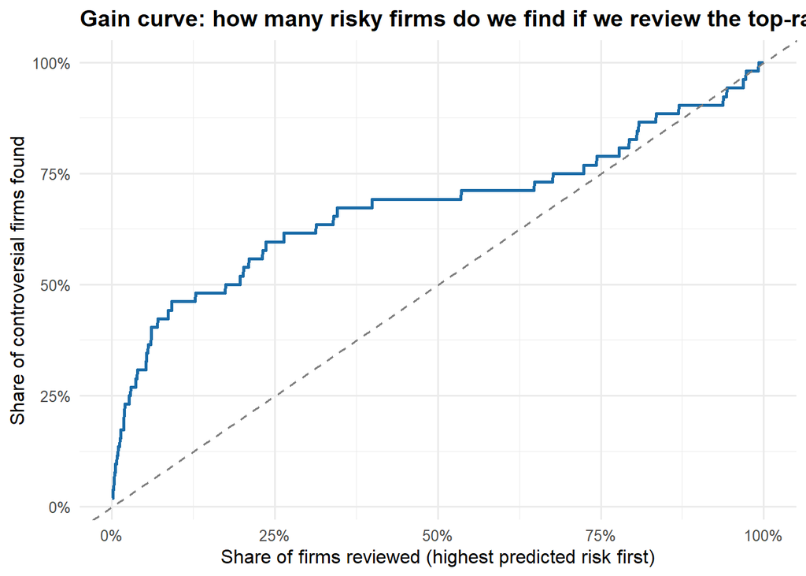

```r
gain_df <- test_pred |>
  arrange(desc(.pred_Yes)) |>
  mutate(pct_tested = row_number() / n(), pct_found = cumsum(env_contro == "Yes") / sum(env_contro == "Yes"))

ggplot(gain_df, aes(pct_tested, pct_found)) +
  geom_line(colour = col_main, linewidth = 1) +
  geom_abline(linetype = "dashed", colour = "grey50") +
  scale_x_continuous(labels = percent) + scale_y_continuous(labels = percent) +
  labs(title = "Gain curve: how many risky firms do we find if we review the top-ranked firms first?",
       x = "Share of firms reviewed (highest predicted risk first)", y = "Share of controversial firms found")
```

```r
boot_stats <- map_dfr(1:500, function(b) {
  i <- sample(nrow(test_pred), replace = TRUE)
  d <- test_pred[i, ]
  tibble(auc = auc_fn(d$env_contro, d$.pred_Yes),
         sens = class_metrics(d$env_contro, d$pred_class)$.estimate[1])
})

tibble(metric = c("ROC AUC", "Sensitivity"),
       estimate = c(auc_fn(test_pred$env_contro, test_pred$.pred_Yes), tm$.estimate[1]),
       lower_95 = c(quantile(boot_stats$auc, 0.025), quantile(boot_stats$sens, 0.025)),
       upper_95 = c(quantile(boot_stats$auc, 0.975), quantile(boot_stats$sens, 0.975))) |>
  kable(digits = 3, caption = "Bootstrap 95% confidence intervals on the test set (500 resamples)")
```

Bootstrap 95% confidence intervals on the test set (500 resamples)

| metric | estimate | lower_95 | upper_95 |
| --- | --- | --- | --- |
| ROC AUC | 0.681 | 0.590 | 0.775 |
| Sensitivity | 0.423 | 0.289 | 0.557 |

**Findings of the test results:**

- The final model is **Elastic-net logistic regression**. On the unseen test set its ROC AUC is **0.681**, compared with a cross-validated value of about 0.707. The two are close, so I do not see strong signs of overfitting, but the test set has few positives, so I still treat the number as approximate.
- With my threshold of **0.053**, the model catches **42%** of the 52 controversial firms in the test set (sensitivity), with a specificity of 93%. The confusion matrix shows 22 true positives, 120 false positives and 30 missed firms (false negatives).
- Precision is only 15%, meaning most flagged firms are *not* controversial. In this task that is acceptable (the scenario says false positives are low cost) but experts should know that most flagged firms will be false alarms. Still, this precision is several times higher than the 2.8% base rate, which shows the model concentrates risk.
- **Accuracy looks worse** (92%) than for the default 0.5 rule (97%), but that is misleading: the default rule is accurate only because it almost never flags a firm. Its sensitivity is just 2%, so it would miss nearly every risky firm. This is the accuracy paradox for imbalanced data.
- The gain curve shows how much better than random the ranking is: the further the curve is above the diagonal, the more controversial firms are found early when experts review firms in order of predicted risk.
- The bootstrap confidence intervals are wide because the test set contains only about 52 positives. I should therefore present performance as a *range* (for example AUC between about 0.59 and 0.78) and not as a precise number.

## 6.10 What drives the predictions? (model interpretation)

I fit the logistic regression and the decision tree on the training data to see which variables matter. These two models are the easiest to explain to a non-technical manager.

### 6.10.1 Logistic regression: odds ratios

The continuous variables are standardised, so each odds ratio shows how the odds of a controversy change when the variable increases by one standard deviation (of its transformed version). A value above 1 means higher risk; below 1 means lower risk. The confidence intervals here are Wald intervals (estimate plus or minus 1.96 standard errors).

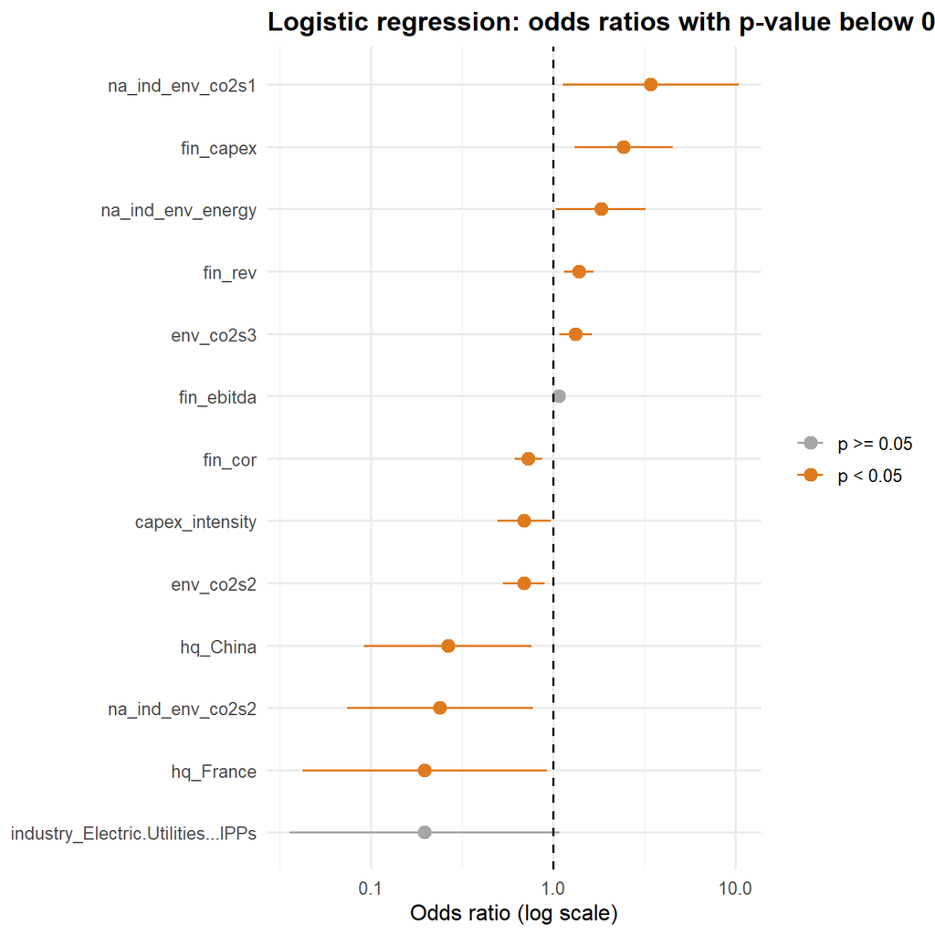

```r
glm_fit <- suppressWarnings(glm(y ~ ., data = cbind(x_of(train_baked), y = y01(train_baked$env_contro)), family = binomial))
cf <- summary(glm_fit)$coefficients
or_tbl <- tibble(term = rownames(cf), estimate = exp(cf[, "Estimate"]),
                 conf.low = exp(cf[, "Estimate"] - 1.96 * cf[, "Std. Error"]),
                 conf.high = exp(cf[, "Estimate"] + 1.96 * cf[, "Std. Error"]),
                 p.value = cf[, "Pr(>|z|)"]) |>
  filter(term != "(Intercept)", !is.na(estimate))

or_tbl |>
  filter(p.value < 0.10) |>
  ggplot(aes(x = estimate, y = reorder(term, estimate), colour = p.value < 0.05)) +
  geom_pointrange(aes(xmin = conf.low, xmax = conf.high)) +
  geom_vline(xintercept = 1, linetype = "dashed") +
  scale_x_log10() +
  scale_colour_manual(values = c("TRUE" = col_accent, "FALSE" = col_grey), labels = c("p >= 0.05", "p < 0.05")) +
  labs(title = "Logistic regression: odds ratios with p-value below 0.10",
       x = "Odds ratio (log scale)", y = NULL, colour = NULL)
```

```r
or_tbl |> arrange(p.value) |> head(10) |>
  select(term, odds_ratio = estimate, conf.low, conf.high, p.value) |>
  kable(digits = 3, caption = "Ten most significant terms in the logistic regression")
```

Ten most significant terms in the logistic regression

| term | odds_ratio | conf.low | conf.high | p.value |
| --- | --- | --- | --- | --- |
| fin_cor | 0.731 | 0.614 | 0.871 | 0.000 |
| fin_rev | 1.384 | 1.150 | 1.665 | 0.001 |
| fin_capex | 2.438 | 1.313 | 4.529 | 0.005 |
| env_co2s2 | 0.689 | 0.529 | 0.898 | 0.006 |
| env_co2s3 | 1.329 | 1.078 | 1.638 | 0.008 |
| hq_China | 0.265 | 0.092 | 0.764 | 0.014 |
| na_ind_env_co2s2 | 0.239 | 0.074 | 0.775 | 0.017 |
| na_ind_env_co2s1 | 3.429 | 1.128 | 10.424 | 0.030 |
| capex_intensity | 0.693 | 0.494 | 0.971 | 0.033 |
| na_ind_env_energy | 1.827 | 1.033 | 3.231 | 0.038 |

### 6.10.2 Decision tree: rules and variable importance

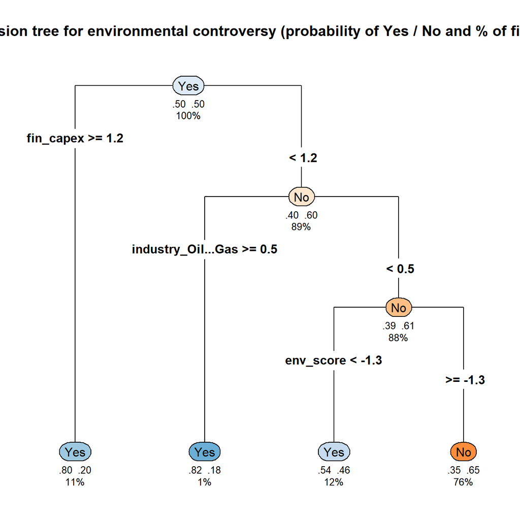

```r
tree_engine <- rpart(env_contro ~ .,
                     data = train_baked,
                     method = "class",
                     parms = list(prior = c(0.5, 0.5)),
                     control = rpart.control(cp = best_tree$cp,
                                             maxdepth = best_tree$maxdepth,
                                             minsplit = best_tree$minsplit,
                                             xval = 0))

# the best tree from tuning is deep (hard to read), so I draw a simplified tree with the same settings but only 3 levels
tree_simple <- rpart(env_contro ~ .,
                     data = train_baked,
                     method = "class",
                     parms = list(prior = c(0.5, 0.5)),
                     control = rpart.control(cp = 0.01,
                                             maxdepth = 3,
                                             minsplit = 60,
                                             xval = 0))

if (nrow(tree_simple$frame) > 1) {
  if (requireNamespace("rpart.plot", quietly = TRUE)) {
    rpart.plot::rpart.plot(tree_simple, type = 4, extra = 104, under = TRUE, roundint = FALSE, box.palette = "BuOr",
                           main = "Decision tree for environmental controversy (probability of Yes / No and % of firms)")
  } else {
    plot(tree_simple, uniform = TRUE, margin = 0.1); text(tree_simple, use.n = TRUE, cex = 0.7)
  }
} else {
  cat("The simplified tree has no splits (a single node), so there is nothing to plot.\n")
}
```

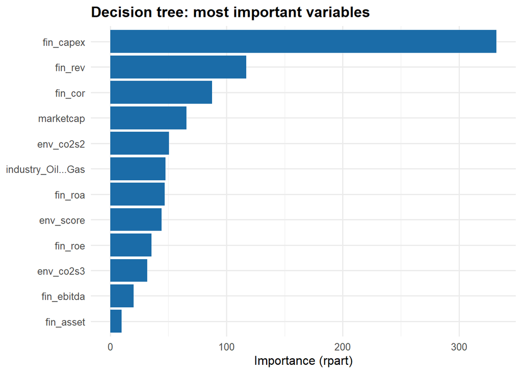

```r
imp <- tree_engine$variable.importance
if (!is.null(imp)) {
  tibble(variable = names(imp), importance = as.numeric(imp)) |>
    slice_max(importance, n = 12) |>
    ggplot(aes(x = importance, y = reorder(variable, importance))) +
    geom_col(fill = col_main) +
    labs(title = "Decision tree: most important variables", x = "Importance (rpart)", y = NULL)
}
```

**Findings:** the tree shows simple “if-then” rules. For readability I draw a simplified three-level tree: the first split is the variable that best separates controversial from non-controversial firms, and boxes with a high share of “Yes” are the high-risk segments that experts should look at first. The variable importance chart comes from the full tuned tree. In my run the most important variables are the size and cost variables (capital expenditure, revenue, cost of revenue and market capitalisation), which agrees with the logistic regression and the clustering result: size drives most of the predictable risk. A single tree is easy to explain, but it is less stable and less accurate than the other models here, so I use it for explanation and not as the final predictor.

## 6.11 Conclusions and recommendations

1. **Best model:** Elastic-net logistic regression gave the best cross-validated ROC AUC (about 0.71) and a test AUC of about 0.68. This is better than chance but only modest, because controversial firms and others overlap heavily on the available data; the bootstrap interval for the test AUC is wide.
2. **How to use it:** use the model as a **ranking and screening tool**. With the chosen threshold it flags about 8% of firms for expert review and catches about 42% of the controversial firms in the test set. Experts can instead review firms from the top of the probability ranking until their capacity runs out (see the gain curve).
3. **Key drivers:** firm size and emissions carry the most predictive information (also visible in the clusters and the tree), and industry (especially oil and gas) and country add context in the exploratory analysis. Firms with many policies are *not* safer: they are often larger and more visible, so having a policy should not be treated as a guarantee.
4. **Why the threshold matters:** because false positives are cheap, I lowered the threshold far below 0.5. The default 0.5 would give impressive accuracy but would miss almost all risky firms.
5. **Limitations:**
   - Only 206 of the 7,275 firms have a controversy, so estimates are uncertain (see the bootstrap intervals).
   - `env_contro` is based on news data, so it measures *media-visible* controversies, which are biased towards large firms in well-covered countries.
   - Many predictors have missing values, which I handled with median imputation and missing-value indicators.
   - The model finds associations, not causes, and it should not be used to blame firms without expert review.

# 7 Overall conclusions:

**1. Most common climate hazards:** Extreme heat, urban flooding and drought are the most reported hazards; by family, flooding / heavy rain, heat and drought / water scarcity affect the most communities. Cities typically face about five hazards at once.

**2. Planned projects and funding by region:** Project counts are spread across regions, but money is concentrated (UKWW dominates). 3 impossible cost values were removed, and a stricter check (excluding costs above the project’s own total cost) is also shown.

**3. Ranked investment opportunities:** 20 waste-management projects from cities with confirmed business collaboration and loan / PPP funding models, ranked by investment cost.

**4. Environmental controversy model:** A cross-validated, threshold-tuned screening model with moderate discriminating power; best used to prioritise firms for expert review.

```r
# 1. Clear variables
rm(list = ls())

# 2. Clear plots
if(!is.null(dev.list())) dev.off()
```

```r
# 3. Free up RAM
gc()
```

```
##           used  (Mb) gc trigger  (Mb) max used  (Mb)
## Ncells 3490417 186.5    7891880 421.5  7891880 421.5
## Vcells 6687653  51.1   23482234 179.2 23482234 179.2
```

# 8 GenAI Declaration

**Tools used:** ChatGPT, Claude and Copilot (generative AI assistants).

**Purpose of use:** brainstorming, understanding and shortening R syntax, troubleshooting code errors, suggesting ways to structure the analysis, and improving explanations and writing.

**Extent of use:** the tools were a supporting aid throughout the assignment, for code suggestions, debugging help and the wording of explanations. They did not produce any results: every table, figure and number in this report comes from running the R code in this file on the supplied datasets, and wherever possible the numbers in the written findings are inserted by inline R code rather than typed by hand. The data-cleaning rules (for example the cost-outlier rules and the definition of a waste project), the choice of methods, the interpretation of results and the final conclusions are my own decisions.

**Steps taken to verify the accuracy of the GenAI output:**

1. I checked every suggested piece of R code against the assignment requirements and ran it myself in R on the supplied dataset.
2. I inspected the data, outputs, statistical results, tables and visualizations myself and checked that the written findings match them.
3. I checked that each suggested method was appropriate for the variables in the data and for the techniques covered in the course.
4. I ran the whole file from a clean R session and confirmed that it knits to HTML without errors.